# MedwithMoni EDA

The goal of this project is to perform exploratory data analysis (EDA) to uncover key insights from scraped Instagram data of medical vloggers and influencers. I aim to identify trends, peak post times, and audience engagement through metrics such as likes, comments, hashtag usage, and video performance. The main priority is to determine the optimal times and frequency for posting.

This version of the EDA is the cut version without the data cleaning process due to the size of the file. This will include some but not all visuals and results of this project.

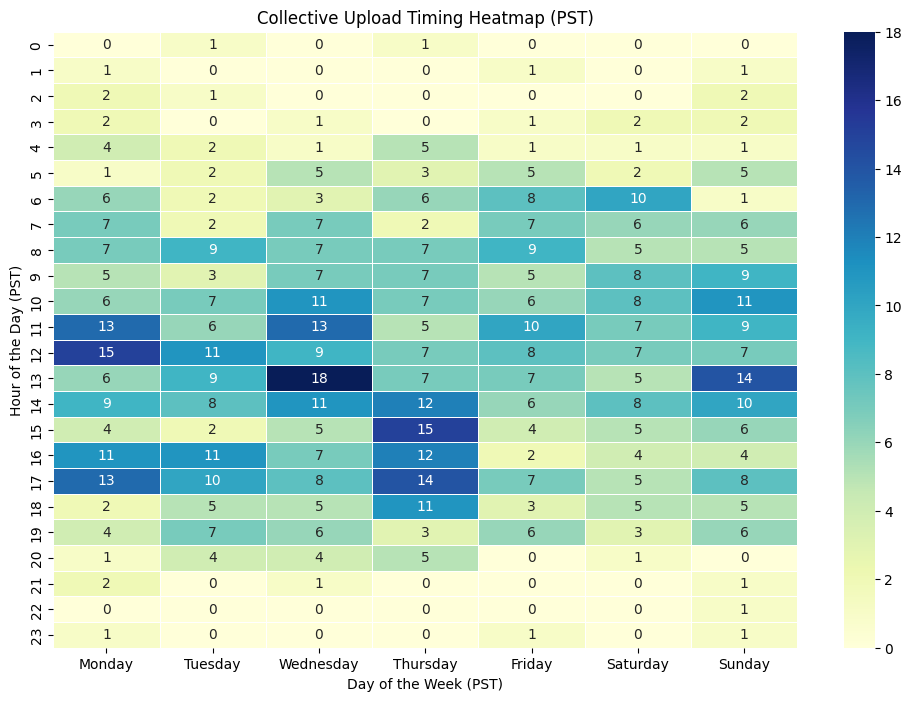

```python
# Ensure datetime_pst is in datetime format
df["datetime_pst"] = pd.to_datetime(df["datetime_pst"])

# Extract hour and date from PST timestamp
df["upload_hour_pst"] = df["datetime_pst"].dt.hour
df["date_pst"] = df["datetime_pst"].dt.date
df["day_of_week_pst"] = df["datetime_pst"].dt.day_name()

# Define correct order of days
day_order = ["Monday", "Tuesday", "Wednesday", "Thursday", "Friday", "Saturday", "Sunday"]

# Convert 'day_of_week_pst' to categorical type with the correct order
df["day_of_week_pst"] = pd.Categorical(df["day_of_week_pst"], categories=day_order, ordered=True)

# Group by PST day of the week and upload hour
upload_heatmap_data = (
    df.groupby(["day_of_week_pst", "upload_hour_pst"], observed=False).size().reset_index(name="upload_count")
)

# Pivot the data for the heatmap
heatmap_pivot = upload_heatmap_data.pivot(
    index="upload_hour_pst", columns="day_of_week_pst", values="upload_count"
)

# Fill NaN values with 0 and convert to integer type
heatmap_pivot = heatmap_pivot.fillna(0).astype(int)

# Plot the heatmap
plt.figure(figsize=(12, 8))
sns.heatmap(heatmap_pivot, cmap="YlGnBu", annot=True, fmt="d", linewidths=0.5)
plt.title("Collective Upload Timing Heatmap (PST)")
plt.xlabel("Day of the Week (PST)")
plt.ylabel("Hour of the Day (PST)")
plt.show()
```

### Trend, Steady and Peak Upload Activity

Considerations for steady upload = 6 videos within an hour Consideration for Peak upload = 10 videos within an hour Monday

- Steady 6AM - 5PM
- Peak 11AM - 5PM

Tuesday

- Steady 8AM - 7PM
- Peak 12PM - 5PM

Wedneday

- Steady 7AM - 5PM
- Peak 10AM - 2PM

Thursday

- Steady 6AM - 6PM
- Peak 2PM - 6PM

Friday

- Steady 6AM - 7PM
- Peak 11AM

Saturday

- Steady 6AM - 2PM
- 6AM

Sunday

- Steady 7AM - 7PM
- 10 AM - 2PM

### Takeaway

Seems like 10AM to 2PM seems stable across majority of the days in terms of peak upload with Thursday being an anomally (2PM to 6PM) where the peak is much later in the day. Needs to be looked into a bit more.

### Note

Given some more context behind uploads, most uploads are done on wednesday and thursday, followed by monday. Other days are are not too far behind with the minimum upload being 92 on Saturdays. Looking at standard deviation, Monday has the largest spread while Wednesday has the lowest spread. Considerations to look at Wednesday as the core. Since uploads seems to visibily be around the same range, Wednesday can be a good indicator of when to best upload. Variations on times between Wednesday and Thursday is upload time. Being that Wednsday is earlier in the day comapred to Thursday being later in the day.

### Next

I'd like to look at the total videos on each hour regardless of days uploaded. To get a better overview of the hours that seems to have the most uploads

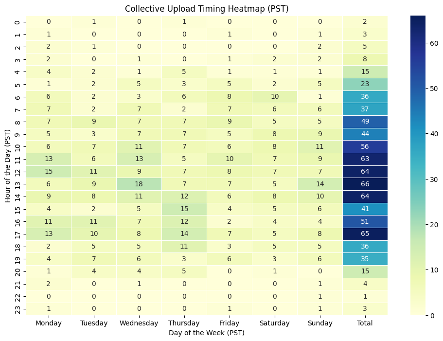

```python
# Ensure datetime_pst is in datetime format
df["datetime_pst"] = pd.to_datetime(df["datetime_pst"])

# Extract hour and date from PST timestamp
df["upload_hour_pst"] = df["datetime_pst"].dt.hour
df["date_pst"] = df["datetime_pst"].dt.date
df["day_of_week_pst"] = df["datetime_pst"].dt.day_name()

# Define correct order of days
day_order = ["Monday", "Tuesday", "Wednesday", "Thursday", "Friday", "Saturday", "Sunday"]

# Convert 'day_of_week_pst' to categorical type with the correct order
df["day_of_week_pst"] = pd.Categorical(df["day_of_week_pst"], categories=day_order, ordered=True)

# Group by PST day of the week and upload hour
upload_heatmap_data = (
    df.groupby(["day_of_week_pst", "upload_hour_pst"], observed=False).size().reset_index(name="upload_count")
)

# Pivot the data for the heatmap
heatmap_pivot = upload_heatmap_data.pivot(
    index="upload_hour_pst", columns="day_of_week_pst", values="upload_count"
)

# Fill NaN values with 0 and convert to integer type
heatmap_pivot = heatmap_pivot.fillna(0).astype(int)

# Add a 'Total' column summing uploads across all days for each hour
heatmap_pivot["Total"] = heatmap_pivot.sum(axis=1)

# Reorder columns to place 'Total' at the end
heatmap_pivot = heatmap_pivot[list(day_order) + ["Total"]]

# Plot the heatmap with the total column
plt.figure(figsize=(12, 8))
sns.heatmap(heatmap_pivot, cmap="YlGnBu", annot=True, fmt="d", linewidths=0.5)
plt.title("Collective Upload Timing Heatmap (PST)")
plt.xlabel("Day of the Week (PST)")
plt.ylabel("Hour of the Day (PST)")
plt.show()
```

### Note

Looks like the largest amount of videos that are closest to each other in terms of total uploads is between 11AM and 2PM then 5PM seems like a strange time where uploads seem high as well. Other horus in between and before do well but not as much as those hours in the 40-50 ranges which is fine. but for consideratiosn when to upload, those time are the most popular it seems.

### Next

These charts helped a lot with looking closer at the details of atleast what time to upload, 11 to 2 seems to be the best spot with 5pm also having large spikes in uploads, i would like to look at comments and likes next to see if time can be narrowed.

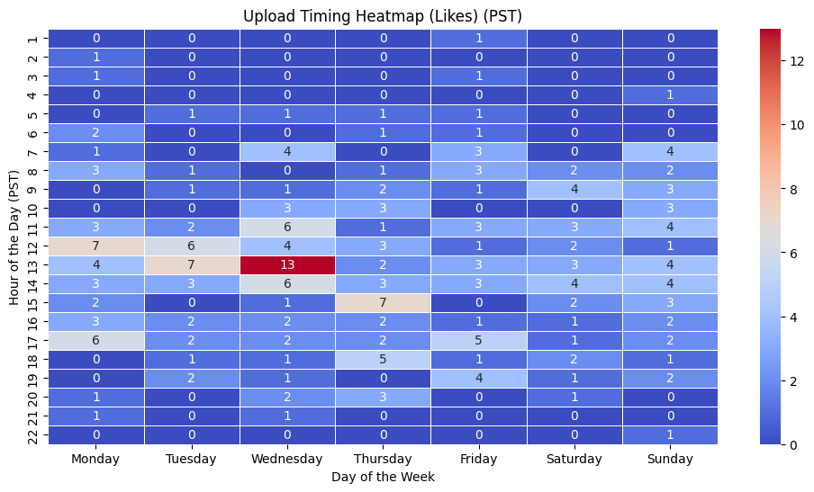

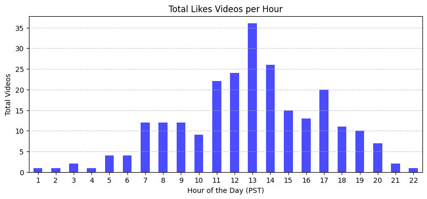

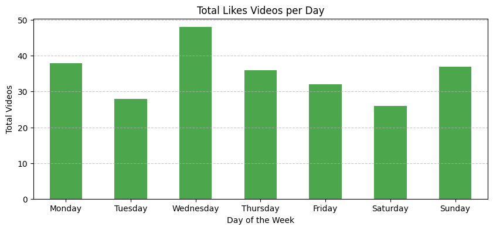

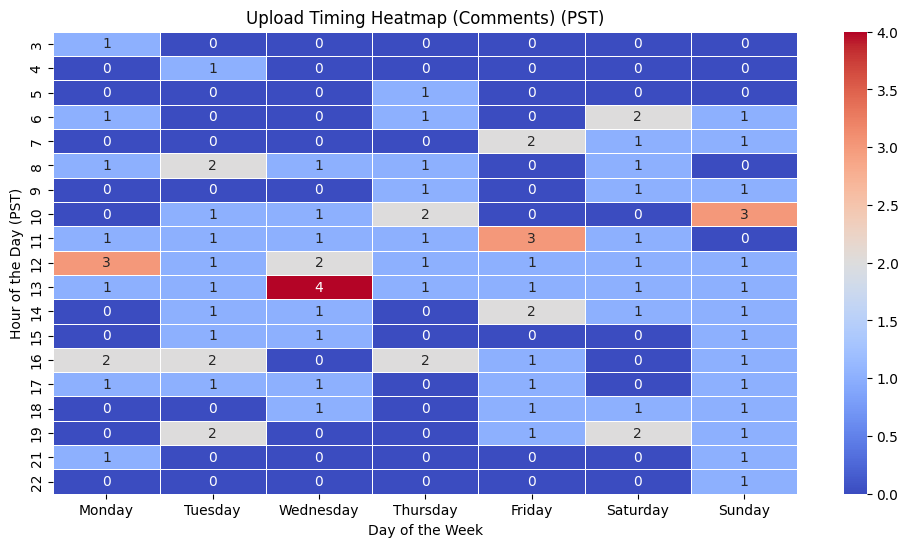

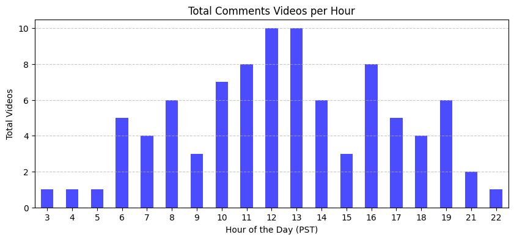

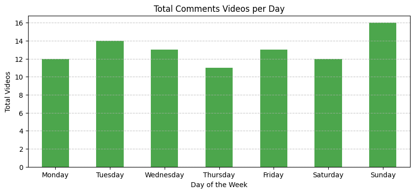

```python
# Convert likes and comments to numeric and clean data
df["likes"] = pd.to_numeric(df["likes"], errors="coerce")
df["comments"] = pd.to_numeric(df["comments"], errors="coerce")
df = df.dropna(subset=["likes", "comments"])

# Define engagement categories
like_bins = [0, 500, 2000, 10000, 50000, float("inf")]
like_labels = ["Low (0-500)", "Medium (500-2K)", "High (2K-10K)", "Very High (10K-50K)", "Viral (50K+)"]

comment_bins = [0, 50, 200, 1000, 5000, float("inf")]
comment_labels = ["Low (0-50)", "Medium (50-200)", "High (200-1K)", "Very High (1K-5K)", "Viral (5K+)"]

df["like_category"] = pd.cut(df["likes"], bins=like_bins, labels=like_labels, include_lowest=True)
df["comment_category"] = pd.cut(df["comments"], bins=comment_bins, labels=comment_labels, include_lowest=True)

# Separate data for Medium & High categories for likes and comments
likes_data = df[df["like_category"].isin(["Medium (500-2K)", "High (2K-10K)"])]
comments_data = df[df["comment_category"].isin(["Medium (50-200)", "High (200-1K)"])]

# Group data separately
likes_heatmap_data = likes_data.groupby(["day_of_week_pst", "upload_hour_pst"]).size().reset_index(name="count")
comments_heatmap_data = comments_data.groupby(["day_of_week_pst", "upload_hour_pst"]).size().reset_index(name="count")

# Function to plot heatmaps and totals
def plot_heatmap_and_totals(data, metric):
    pivot_data = data.pivot(index="upload_hour_pst", columns="day_of_week_pst", values="count")

    # Heatmap Plot
    plt.figure(figsize=(12, 6))
    sns.heatmap(pivot_data, cmap="coolwarm", annot=True, fmt="d", linewidths=0.5)
    plt.title(f"Upload Timing Heatmap ({metric}) (PST)")
    plt.xlabel("Day of the Week")
    plt.ylabel("Hour of the Day (PST)")
    plt.show()

    # Total Videos per Hour (Bar Chart)
    row_totals = pivot_data.sum(axis=1)  # Total per hour
    plt.figure(figsize=(10, 4))
    row_totals.plot(kind="bar", color="blue", alpha=0.7)
    plt.title(f"Total {metric} Videos per Hour")
    plt.xlabel("Hour of the Day (PST)")
    plt.ylabel("Total Videos")
    plt.xticks(rotation=0)
    plt.grid(axis="y", linestyle="--", alpha=0.7)
    plt.show()

    # Total Videos per Day (Bar Chart)
    col_totals = pivot_data.sum(axis=0)  # Total per day
    plt.figure(figsize=(10, 4))
    col_totals.plot(kind="bar", color="green", alpha=0.7)
    plt.title(f"Total {metric} Videos per Day")
    plt.xlabel("Day of the Week")
    plt.ylabel("Total Videos")
    plt.xticks(rotation=0)
    plt.grid(axis="y", linestyle="--", alpha=0.7)
    plt.show()

# Generate visualizations for Likes and Comments separately
plot_heatmap_and_totals(likes_heatmap_data, "Likes")
plot_heatmap_and_totals(comments_heatmap_data, "Comments")
```

### Note

Found pretty high total count of likes and comments on Wednesday at 1PM, all around though it seems that 11AM to 2PM with 5PM being somewhat special in terms of user uploading and being successful as well. Days wise, it seems that Wednesday is arguably probably the most poopular day to upload and find success but all other days seem to be not that far behind. Upload wise it looks like the goal is to upload around 11AM to 2PM for consistency sake and 5PM if the user wanted to upload something a bit later in the day. Days wise, Id like to look at upload schedules and consistency of these users and see how often they post.

## Upload Frequency

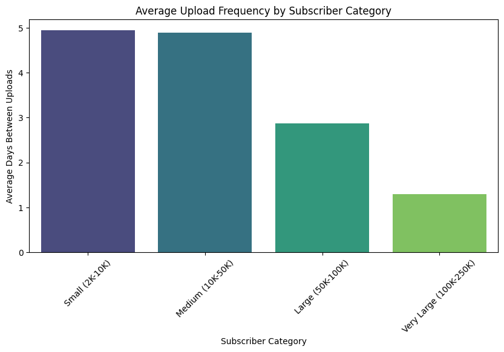

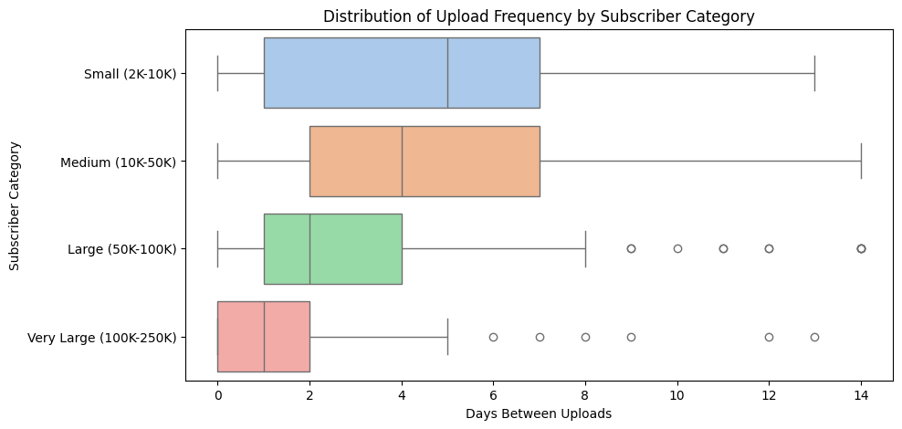

```python
# Ensure 'datetime_pst' is in datetime format
df_filtered["datetime_pst"] = pd.to_datetime(df_filtered["datetime_pst"])

# Sort by username and datetime
df_filtered = df_filtered.sort_values(by=["username", "datetime_pst"])

# Calculate days between uploads per user
df_filtered["days_between_uploads"] = df_filtered.groupby("username")["datetime_pst"].diff().dt.days

# Remove outliers
df_filtered = df_filtered[df_filtered["days_between_uploads"] <= 14]

# Group by subscriber category and calculate the mean days between uploads
avg_days = df_filtered.groupby("subscriber_category", observed=True)["days_between_uploads"].mean().reset_index()

# Bar Chart: Average Days Between Uploads ---
plt.figure(figsize=(10, 5))
sns.barplot(data=avg_days, x="subscriber_category", y="days_between_uploads", hue="subscriber_category", palette="viridis", legend=False)
plt.xlabel("Subscriber Category")
plt.ylabel("Average Days Between Uploads")
plt.title("Average Upload Frequency by Subscriber Category")
plt.xticks(rotation=45)
plt.show()

# Box Plot: Distribution of Upload Frequency ---
plt.figure(figsize=(10, 5))
sns.boxplot(data=df_filtered, y="subscriber_category", x="days_between_uploads", hue="subscriber_category", palette="pastel", legend=False, orient="h")
plt.ylabel("Subscriber Category")
plt.xlabel("Days Between Uploads")
plt.title("Distribution of Upload Frequency by Subscriber Category")
plt.show()
```

## Hashtags

A look at hashtags to see the average per video and see the most popular ones.

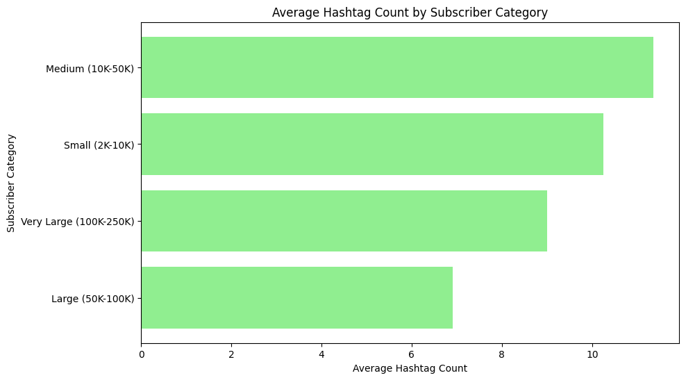

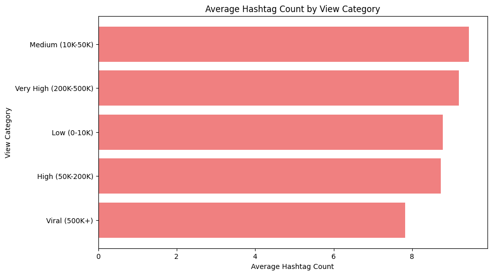

```python
# Plot for Average Hashtags by Subscriber Category
plt.figure(figsize=(10, 6))
plt.barh(avg_hashtags_by_subscriber_category['subscriber_category'],
         avg_hashtags_by_subscriber_category['hashtag_count'],
         color='lightgreen')
plt.xlabel('Average Hashtag Count')
plt.ylabel('Subscriber Category')
plt.title('Average Hashtag Count by Subscriber Category')
plt.gca().invert_yaxis()
plt.show()

# Plot for Average Hashtags by View Category
plt.figure(figsize=(10, 6))
plt.barh(avg_hashtags_by_view_category['view_category'],
         avg_hashtags_by_view_category['hashtag_count'],
         color='lightcoral')
plt.xlabel('Average Hashtag Count')
plt.ylabel('View Category')
plt.title('Average Hashtag Count by View Category')
plt.gca().invert_yaxis()
plt.show()
```

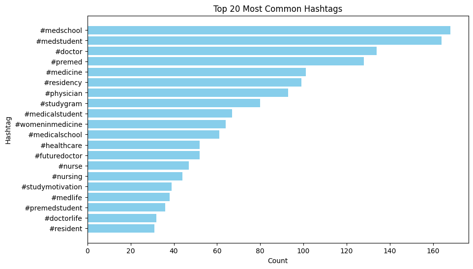

```python
import matplotlib.pyplot as plt
from collections import Counter

# Split the hashtags and flatten the lists
all_hashtags = df_hashtags['hashtags'].str.split().explode().dropna()

# Optionally, remove empty strings or unwanted characters
all_hashtags = all_hashtags[all_hashtags.str.strip() != '']

# Count the occurrences of each hashtag
hashtag_counts = Counter(all_hashtags)

# Get the 10 most common hashtags
top_hashtags = hashtag_counts.most_common(20)

# Unzip the list of tuples into two separate lists: hashtags and counts
hashtags, counts = zip(*top_hashtags)

# Create a bar chart
plt.figure(figsize=(10, 6))
plt.barh(hashtags, counts, color='skyblue')
plt.xlabel('Count')
plt.ylabel('Hashtag')
plt.title('Top 20 Most Common Hashtags')
plt.gca().invert_yaxis()  # Invert the y-axis to display the highest count on top
plt.show()
```

```python
# Function to get top 5 hashtags for each category
def top_hashtags_by_category(df, category_column, hashtag_column):
    top_hashtags = {}

    for category in df[category_column].unique():
        # Filter hashtags for the category
        category_hashtags = df[df[category_column] == category][hashtag_column].str.split().explode().dropna()

        # Count the occurrences of each hashtag
        hashtag_counts = Counter(category_hashtags)

        # Get the top 10 most common hashtags for category
        top_category_hashtags = hashtag_counts.most_common(5)

        # Store the results in the dictionary
        top_hashtags[category] = top_category_hashtags

    return top_hashtags

# Get the top 5 hashtags by subscriber category
top_hashtags_by_subscriber_category = top_hashtags_by_category(df_hashtags, 'subscriber_category', 'hashtags')

# Define the order for subscriber categories from Small to Very Large
category_order = ['Small (2K-10K)', 'Medium (10K-50K)', 'Large (50K-100K)', 'Very Large (100K-250K)']

# Sort the dictionary by the predefined category order
sorted_top_hashtags_by_subscriber_category = {category: top_hashtags_by_subscriber_category[category]
                                              for category in category_order
                                              if category in top_hashtags_by_subscriber_category}

# Display the results for subscriber category in the order
print("Top 10 Hashtags by Subscriber Category (Sorted):")
for category, hashtags in sorted_top_hashtags_by_subscriber_category.items():
    print(f"\n{category}:")
    for hashtag, count in hashtags:
        print(f"  {hashtag}: {count}")
```

```
Top 10 Hashtags by Subscriber Category (Sorted):

Small (2K-10K):
  #medstudent: 35
  #medschool: 29
  #medgram: 23
  #studygram: 20
  #womeninstem: 16

Medium (10K-50K):
  #studygram: 57
  #medstudent: 53
  #medschool: 48
  #studymotivation: 37
  #studyblr: 28

Large (50K-100K):
  #premed: 77
  #doctor: 74
  #medstudent: 55
  #medschool: 47
  #medicine: 37

Very Large (100K-250K):
  #doctor: 60
  #physician: 56
  #residency: 50
  #healthcare: 47
  #medschool: 44
```

```python
# Create function to get top 5 hashtags by each category order by count
def top_hashtags_by_category(df, category_column, hashtag_column):
    top_hashtags = {}

    # Category range
    category_order = ['Low (0-10K)', 'Medium (10K-50K)', 'High (50K-200K)', 'Very High (200K-500K)', 'Viral (500K+)']

    # Sort by category order
    for category in category_order:
        # Filter hashtags for the category
        category_hashtags = df[df[category_column] == category][hashtag_column].str.split().explode().dropna()

        # Count the occurrences of each hashtag
        hashtag_counts = Counter(category_hashtags)

        # Get the top 5 most common hashtags for this category
        top_category_hashtags = sorted(hashtag_counts.items(), key=lambda x: x[1], reverse=True)[:5]

        # Store results into dictionary
        top_hashtags[category] = top_category_hashtags

    return top_hashtags

# Top 5 hashtags by view
top_hashtags_by_view_category = top_hashtags_by_category(df_hashtags, 'view_category', 'hashtags')

# Display results for view category, sort by count
print("\nTop 5 Hashtags by View Category:")
for category, hashtags in top_hashtags_by_view_category.items():
    print(f"\n{category}:")
    for hashtag, count in hashtags:
        print(f"  {hashtag}: {count}")
```

```
Top 5 Hashtags by View Category:

Low (0-10K):
  #medstudent: 57
  #studygram: 49
  #medschool: 40
  #premed: 23
  #studymotivation: 23

Medium (10K-50K):
  #medschool: 97
  #doctor: 89
  #medstudent: 76
  #premed: 72
  #medicine: 71

High (50K-200K):
  #medschool: 17
  #doctor: 17
  #premed: 17
  #residency: 15
  #physician: 14

Very High (200K-500K):
  #doctor: 9
  #medstudent: 7
  #premed: 7
  #medschool: 5
  #premedstudent: 5

Viral (500K+):
  #doctor: 15
  #medstudent: 11
  #medicalschool: 10
  #medschool: 9
  #premed: 9
```

```python
# Dictionaries based on scubscriber count
data_first_set = {
    'Category (Subscribers)': [
        'Small (2K-10K)', 'Small (2K-10K)', 'Small (2K-10K)', 'Small (2K-10K)', 'Small (2K-10K)',
        'Medium (10K-50K)', 'Medium (10K-50K)', 'Medium (10K-50K)', 'Medium (10K-50K)', 'Medium (10K-50K)',
        'Large (50K-100K)', 'Large (50K-100K)', 'Large (50K-100K)', 'Large (50K-100K)', 'Large (50K-100K)',
        'Very Large (100K-250K)', 'Very Large (100K-250K)', 'Very Large (100K-250K)', 'Very Large (100K-250K)', 'Very Large (100K-250K)'
    ],
    'Hashtag': [
        '#medstudent', '#medschool', '#medgram', '#studygram', '#womeninstem',
        '#studygram', '#medstudent', '#medschool', '#studymotivation', '#studyblr',
        '#premed', '#doctor', '#medstudent', '#medschool', '#medicine',
        '#doctor', '#physician', '#residency', '#healthcare', '#medschool'
    ],
    'Count': [
        35, 29, 23, 20, 16,
        57, 53, 48, 37, 28,
        77, 74, 55, 47, 37,
        60, 56, 50, 47, 44
    ]
}

# Define the data as a dictionary for the second set based on Video Views
data_second_set = {
    'Category (Video Views)': [
        'Low (0-10K)', 'Low (0-10K)', 'Low (0-10K)', 'Low (0-10K)', 'Low (0-10K)',
        'Medium (10K-50K)', 'Medium (10K-50K)', 'Medium (10K-50K)', 'Medium (10K-50K)', 'Medium (10K-50K)',
        'High (50K-200K)', 'High (50K-200K)', 'High (50K-200K)', 'High (50K-200K)', 'High (50K-200K)',
        'Very High (200K-500K)', 'Very High (200K-500K)', 'Very High (200K-500K)', 'Very High (200K-500K)', 'Very High (200K-500K)',
        'Viral (500K+)','Viral (500K+)','Viral (500K+)','Viral (500K+)','Viral (500K+)'
    ],
    'Hashtag': [
        '#medstudent', '#studygram', '#medschool', '#premed', '#studymotivation',
        '#medschool', '#doctor', '#medstudent', '#premed', '#medicine',
        '#medschool', '#doctor', '#premed', '#residency', '#physician',
        '#doctor', '#medstudent', '#premed', '#medschool', '#premedstudent',
        '#doctor', '#medstudent', '#medicalschool', '#medschool', '#premed'
    ],
    'Count': [
        57, 49, 40, 23, 23,
        97, 89, 76, 72, 71,
        17, 17, 17, 15, 14,
        9, 7, 7, 5, 5,
        15, 11, 10, 9, 9
    ]
}

# Dataframes for dictionaries
df_first_set = pd.DataFrame(data_first_set)
df_second_set = pd.DataFrame(data_second_set)

# Print in readable format
def print_table(df, title):
    print(f"\n{title}:")
    table = tabulate(df, headers='keys', tablefmt='fancy_grid', showindex=False)
    print(table)
    print("\n" + "-"*60)

# Display the tables
print_table(df_first_set, "Top 5 Hashtags Based on Subscribers")
print_table(df_second_set, "Top 5 Hashtags Based on Video Views")
```

```
Top 5 Hashtags Based on Subscribers:
╒══════════════════════════╤══════════════════╤═════════╕
│ Category (Subscribers)   │ Hashtag          │   Count │
╞══════════════════════════╪══════════════════╪═════════╡
│ Small (2K-10K)           │ #medstudent      │      35 │
├──────────────────────────┼──────────────────┼─────────┤
│ Small (2K-10K)           │ #medschool       │      29 │
├──────────────────────────┼──────────────────┼─────────┤
│ Small (2K-10K)           │ #medgram         │      23 │
├──────────────────────────┼──────────────────┼─────────┤
│ Small (2K-10K)           │ #studygram       │      20 │
├──────────────────────────┼──────────────────┼─────────┤
│ Small (2K-10K)           │ #womeninstem     │      16 │
├──────────────────────────┼──────────────────┼─────────┤
│ Medium (10K-50K)         │ #studygram       │      57 │
├──────────────────────────┼──────────────────┼─────────┤
│ Medium (10K-50K)         │ #medstudent      │      53 │
├──────────────────────────┼──────────────────┼─────────┤
│ Medium (10K-50K)         │ #medschool       │      48 │
├──────────────────────────┼──────────────────┼─────────┤
│ Medium (10K-50K)         │ #studymotivation │      37 │
├──────────────────────────┼──────────────────┼─────────┤
│ Medium (10K-50K)         │ #studyblr        │      28 │
├──────────────────────────┼──────────────────┼─────────┤
│ Large (50K-100K)         │ #premed          │      77 │
├──────────────────────────┼──────────────────┼─────────┤
│ Large (50K-100K)         │ #doctor          │      74 │
├──────────────────────────┼──────────────────┼─────────┤
│ Large (50K-100K)         │ #medstudent      │      55 │
├──────────────────────────┼──────────────────┼─────────┤
│ Large (50K-100K)         │ #medschool       │      47 │
├──────────────────────────┼──────────────────┼─────────┤
│ Large (50K-100K)         │ #medicine        │      37 │
├──────────────────────────┼──────────────────┼─────────┤
│ Very Large (100K-250K)   │ #doctor          │      60 │
├──────────────────────────┼──────────────────┼─────────┤
│ Very Large (100K-250K)   │ #physician       │      56 │
├──────────────────────────┼──────────────────┼─────────┤
│ Very Large (100K-250K)   │ #residency       │      50 │
├──────────────────────────┼──────────────────┼─────────┤
```

[output cut: 48 more lines]

```
├──────────────────────────┼──────────────────┼─────────┤
│ Very High (200K-500K)    │ #premedstudent   │       5 │
├──────────────────────────┼──────────────────┼─────────┤
│ Viral (500K+)            │ #doctor          │      15 │
├──────────────────────────┼──────────────────┼─────────┤
│ Viral (500K+)            │ #medstudent      │      11 │
├──────────────────────────┼──────────────────┼─────────┤
│ Viral (500K+)            │ #medicalschool   │      10 │
├──────────────────────────┼──────────────────┼─────────┤
│ Viral (500K+)            │ #medschool       │       9 │
├──────────────────────────┼──────────────────┼─────────┤
│ Viral (500K+)            │ #premed          │       9 │
╘══════════════════════════╧══════════════════╧═════════╛

------------------------------------------------------------
```

[figure not shown]

```python
from wordcloud import WordCloud

# Combine hashtags from all categories into one list
all_hashtags = df_hashtags['hashtags'].str.split().explode().dropna()

# Create a Word Cloud for all hashtags
wordcloud = WordCloud(width=800, height=400, background_color='white').generate(' '.join(all_hashtags))

# Plot the word cloud
plt.figure(figsize=(10, 6))
plt.imshow(wordcloud, interpolation='bilinear')
plt.axis('off')
plt.show()
```